# Relación entre el autoestima y las reuniones sociales constantes

Octubre 1, 2021

## Autoestima Reuniones Sociales

- Ayelen Catacora Juanillo 202010225Líder
- Mayra Díaz Tramontana 201910147
- Walter Gonzalo Gonzales Cruz 202110468
- Derkhenz Ezer Valera Nuez 201910470
- Jelser Arturo Saldaña Mas 202020140

## Tema

### Autoestima e interacciones sociales estudiantes de la UTEC durante el periodo 2020-2021

Las interacciones sociales ya sea, de manera presencial o virtual, tiene cierto impacto en la autoestima e imagen personal de una persona. Para comprobar esto, se hará un estudio estadístico en la cual nuestra población objeto de estudio serán los adultos jóvenes, estudiantes de UTEC, en Lima.

## Sobre la investigación

### Objetivo

Buscamos comprobar si existe una relación entre el autoestima y la imagen personal de una persona con respecto a la frecuencia y calidad de sus interacciones sociales. Por lo tanto, de existir tal relación, se buscará identificar que aspectos son de mayor relevancia e impacto en el autoestima y la frecuencia y calidad de actividades sociales de una persona.

### Factabilidad

Para lograr llegar a la información que se propone de manera específica y concreta se planea realizar 150 encuestas. A adultos jóvenes, estudiantes de UTEC, en Lima en el 2020-2021, pues son nuestro público objetivo. Dicha encuesta constará de tres partes:

- Información básica Recolectaremos el sexo y la edad.
- Interacciones sociales Preguntas acerca de la calidad y frecuencia de sus interacciones sociales son distintos grupos (familia y amigos).
- Visión personal Preguntas referentes a el autoestima y la imagen personal.

## Preguntas de investigación

¿Existe una relación entre la imagen personal y la calidad y frecuencia de las interacciones sociales de un estudiante de UTEC en Lima, en el periodo 2020-2021?

## Marco Teórico

- Población: Estudiantes de UTEC en Lima en el periodo 2020-2021
- Unidad muestral: Cada estudiante de UTEC
- Tipo de muestreo: Muestreo no porbabilístico por conveniencia

### Obtención de datos

Para el presente trabajo de investigación, se decidió emplear encuestas con Google Forms, para así poder recopilar la información de los participantes. A fin de asegurar la veracidad y procedencia de los datos, se restringió el acceso a la encuesta a aquellos usuarios que tengan una cuenta de Google que pertenece al dominio de UTEC, es decir, usuarios de la Universidad de Ingeniería y Tecnología.

## Variables

| Pregunta | Variable | Tipo de variable | Restricciones |
| --- | --- | --- | --- |
| Escriba su edad | Edad | Numérica discreta | Número entero |
| Seleccione su sexo | Sexo | Categórica nominal | Femenino, Masculino, Otro |
| ¿Cuántas veces al mes se reúne con sus familiares? | Frecuencia de reuniones familiares | Numérica continua | Número entero |
| ¿Cuántas veces al mes se reúne con sus amigos? | Frecuencia de reuniones amicales | Numérica continua | Número entero |
| ¿Cuántas veces al mes organiza algún evento social? | Frecuencia de organización de eventos | Numérica continua | Número entero |
| ¿Cuántos minutos al día pasas con las personas con las que vives? | Minutos diarios con familia | Numérica continua | Número entero |
| ¿Cuántos minutos al día conversas con tus amigos? | Minutos diarios con amigos | Numérica continua | Número entero |

## Variables

[output not shown]

## Variables

| Pregunta | Variable | Tipo de variable | Restricciones |
| --- | --- | --- | --- |
| Qué tan satisfecha estás con tu personalidad actualmente | Satisfacción personal de personalidad | Categórica ordinal | Número entero en el intervalo [1;5] |
| ¿Se ha sentido ofendido alguna vez por lo que ha dicho otra persona? | Experiencia de haber sido ofendido | Categórica nominal | Sí, No |
| ¿Cuando está con amigos/as, puede relajarse y ser usted mismo/a? | Comodidad con amigos | Categórica nominal | Sí, No, A veces |
| ¿Cuánto te preocupa la impresión que causas sobre los demás? | Preocupación de opinión ajena | Categórica ordinal | Número entero en el intervalo [1;5] |
| ¿Cuántas veces al año realizas introspección a tu persona? | Frecuencia de introspección | Categórica nominal | Nunca, 1 vez al año, Más de 2 veces al año. |

## Base de datos

```
##     Marca                Edad           Sexo            FRFamiliares
##  Length:81          Min.   :16.00   Length:81          Min.   : 0.000
##  Class :character   1st Qu.:19.00   Class :character   1st Qu.: 2.000
##  Mode  :character   Median :20.00   Mode  :character   Median : 4.000
##                     Mean   :20.94                      Mean   : 4.321
##                     3rd Qu.:21.00                      3rd Qu.: 5.000
##                     Max.   :48.00                      Max.   :30.000
##    FRAmicales      FROrgEventos      MDFamilia         MDAmigos
##  Min.   : 0.000   Min.   : 0.000   Min.   :   5.0   Min.   :   2.0
##  1st Qu.: 1.000   1st Qu.: 0.000   1st Qu.:  60.0   1st Qu.:  60.0
##  Median : 3.000   Median : 1.000   Median : 150.0   Median : 120.0
##  Mean   : 3.321   Mean   : 1.691   Mean   : 240.4   Mean   : 178.8
##  3rd Qu.: 4.000   3rd Qu.: 2.000   3rd Qu.: 240.0   3rd Qu.: 190.0
##  Max.   :30.000   Max.   :10.000   Max.   :1440.0   Max.   :1500.0
##    CIFamiliaN      CIFamiliaG       CIAmigos      PAsertividad
##  Min.   :1.000   Min.   :2.000   Min.   :1.000   Min.   :1.000
##  1st Qu.:4.000   1st Qu.:3.000   1st Qu.:3.000   1st Qu.:3.000
##  Median :5.000   Median :4.000   Median :4.000   Median :4.000
##  Mean   :4.296   Mean   :3.704   Mean   :4.062   Mean   :3.926
##  3rd Qu.:5.000   3rd Qu.:4.000   3rd Qu.:5.000   3rd Qu.:5.000
##  Max.   :5.000   Max.   :5.000   Max.   :5.000   Max.   :5.000
##  Autoconocimiento   SPersonal        SFisica      SPersonalidad
##  Min.   : 4.000   Min.   :2.000   Min.   :1.000   Min.   :2.000
##  1st Qu.: 7.000   1st Qu.:3.000   1st Qu.:3.000   1st Qu.:3.000
##  Median : 8.000   Median :4.000   Median :4.000   Median :4.000
##  Mean   : 8.025   Mean   :3.852   Mean   :3.469   Mean   :3.963
##  3rd Qu.: 9.000   3rd Qu.:5.000   3rd Qu.:4.000   3rd Qu.:5.000
##  Max.   :10.000   Max.   :5.000   Max.   :5.000   Max.   :5.000
##    EOfensa           ComodidadA        POpinionAjena   FIntrospeccion
##  Length:81          Length:81          Min.   :1.000   Length:81
##  Class :character   Class :character   1st Qu.:3.000   Class :character
##  Mode  :character   Mode  :character   Median :3.000   Mode  :character
##                                        Mean   :3.321
##                                        3rd Qu.:4.000
##                                        Max.   :5.000
```

## Datos

```
##     Marca                Edad           Sexo            FRFamiliares
##  Length:81          Min.   :16.00   Length:81          Min.   : 0.000
##  Class :character   1st Qu.:19.00   Class :character   1st Qu.: 2.000
##  Mode  :character   Median :20.00   Mode  :character   Median : 4.000
##                     Mean   :20.94                      Mean   : 4.321
##                     3rd Qu.:21.00                      3rd Qu.: 5.000
##                     Max.   :48.00                      Max.   :30.000
##    FRAmicales      FROrgEventos      MDFamilia         MDAmigos
##  Min.   : 0.000   Min.   : 0.000   Min.   :   5.0   Min.   :   2.0
##  1st Qu.: 1.000   1st Qu.: 0.000   1st Qu.:  60.0   1st Qu.:  60.0
##  Median : 3.000   Median : 1.000   Median : 150.0   Median : 120.0
##  Mean   : 3.321   Mean   : 1.691   Mean   : 240.4   Mean   : 178.8
##  3rd Qu.: 4.000   3rd Qu.: 2.000   3rd Qu.: 240.0   3rd Qu.: 190.0
##  Max.   :30.000   Max.   :10.000   Max.   :1440.0   Max.   :1500.0
##    CIFamiliaN      CIFamiliaG       CIAmigos      PAsertividad
##  Min.   :1.000   Min.   :2.000   Min.   :1.000   Min.   :1.000
##  1st Qu.:4.000   1st Qu.:3.000   1st Qu.:3.000   1st Qu.:3.000
##  Median :5.000   Median :4.000   Median :4.000   Median :4.000
##  Mean   :4.296   Mean   :3.704   Mean   :4.062   Mean   :3.926
##  3rd Qu.:5.000   3rd Qu.:4.000   3rd Qu.:5.000   3rd Qu.:5.000
##  Max.   :5.000   Max.   :5.000   Max.   :5.000   Max.   :5.000
##  Autoconocimiento   SPersonal        SFisica      SPersonalidad
##  Min.   : 4.000   Min.   :2.000   Min.   :1.000   Min.   :2.000
##  1st Qu.: 7.000   1st Qu.:3.000   1st Qu.:3.000   1st Qu.:3.000
##  Median : 8.000   Median :4.000   Median :4.000   Median :4.000
##  Mean   : 8.025   Mean   :3.852   Mean   :3.469   Mean   :3.963
##  3rd Qu.: 9.000   3rd Qu.:5.000   3rd Qu.:4.000   3rd Qu.:5.000
##  Max.   :10.000   Max.   :5.000   Max.   :5.000   Max.   :5.000
##    EOfensa           ComodidadA        POpinionAjena   FIntrospeccion
##  Length:81          Length:81          Min.   :1.000   Length:81
##  Class :character   Class :character   1st Qu.:3.000   Class :character
##  Mode  :character   Mode  :character   Median :3.000   Mode  :character
##                                        Mean   :3.321
##                                        3rd Qu.:4.000
##                                        Max.   :5.000
```

```
## # A tibble: 6 × 20
##   Marca      Edad Sexo   FRFamiliares FRAmicales FROrgEventos MDFamilia MDAmigos
##   <chr>     <dbl> <chr>         <dbl>      <dbl>        <dbl>     <dbl>    <dbl>
## 1 29/09/20…    17 Femen…            3          1            2       120       90
## 2 29/09/20…    19 Mascu…            1          2            2       360      120
## 3 29/09/20…    19 Femen…            3          2            3        60      300
## 4 29/09/20…    24 Mascu…            4          4            4        60      240
## 5 29/09/20…    19 Femen…            4          1            1       300      100
## 6 29/09/20…    19 Femen…            8          2            1       180       60
## # … with 12 more variables: CIFamiliaN <dbl>, CIFamiliaG <dbl>, CIAmigos <dbl>,
## #   PAsertividad <dbl>, Autoconocimiento <dbl>, SPersonal <dbl>, SFisica <dbl>,
## #   SPersonalidad <dbl>, EOfensa <chr>, ComodidadA <chr>, POpinionAjena <dbl>,
## #   FIntrospeccion <chr>
```

## Análisis

### Frecuencia de reuniones familiares

```
##    Min. 1st Qu.  Median    Mean 3rd Qu.    Max.
##   0.000   2.000   4.000   4.321   5.000  30.000
```

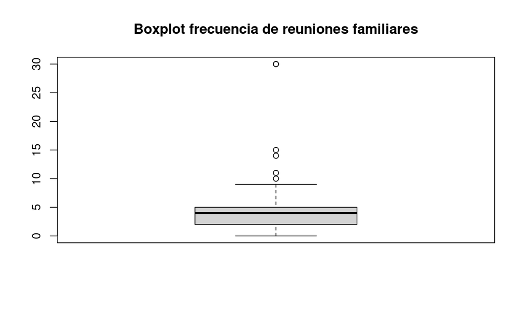

## Análisis

### Frecuencia de reuniones amicales

```
##    Min. 1st Qu.  Median    Mean 3rd Qu.    Max.
##   0.000   1.000   3.000   3.321   4.000  30.000
```

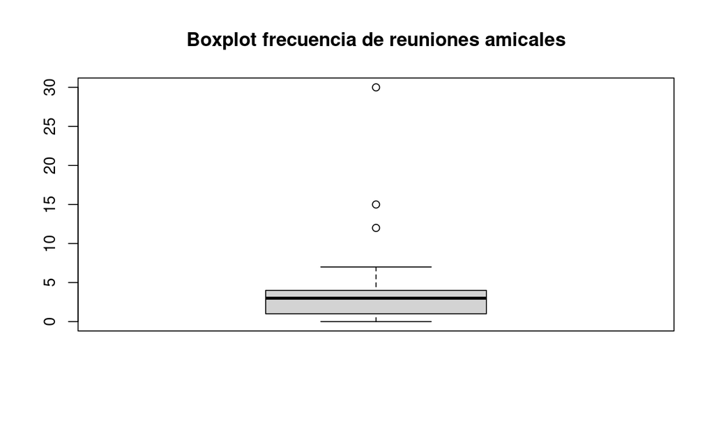

## Análisis

### Frecuencia de organización de eventos

```
##    Min. 1st Qu.  Median    Mean 3rd Qu.    Max.
##   0.000   0.000   1.000   1.691   2.000  10.000
```

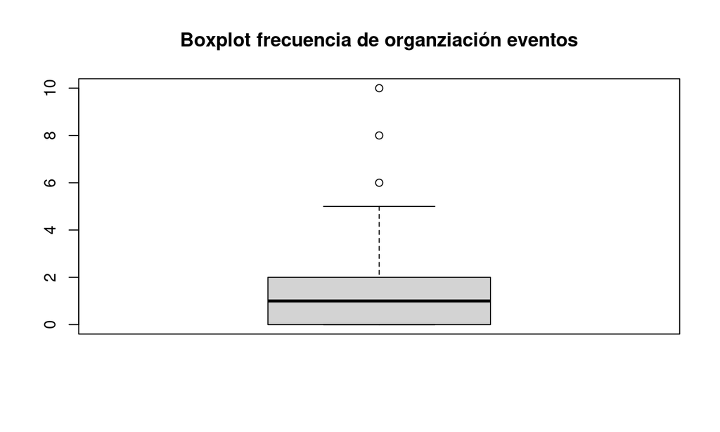

## Análisis

### Minutos pasados al día con familia

```
##    Min. 1st Qu.  Median    Mean 3rd Qu.    Max.
##     5.0    60.0   150.0   240.4   240.0  1440.0
```

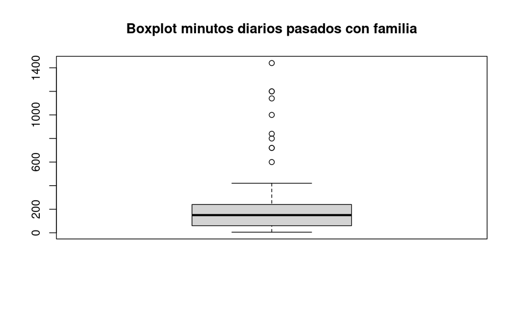

## Análisis

### Minutos pasados al día con amigos

```
##    Min. 1st Qu.  Median    Mean 3rd Qu.    Max.
##     2.0    60.0   120.0   178.8   190.0  1500.0
```

[figure not shown]

## Análisis

### Visión personal

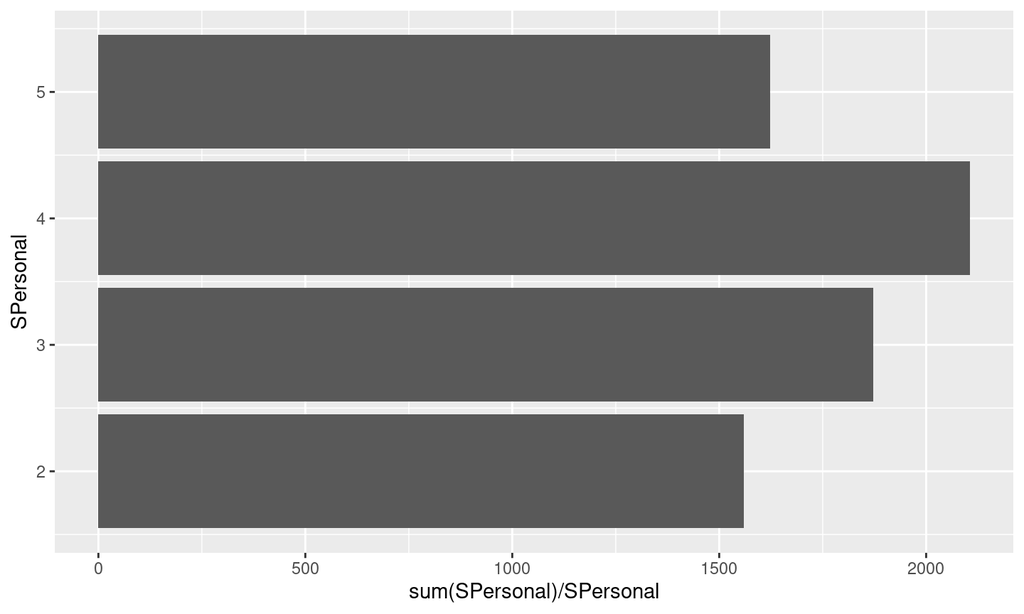

## Análisis

### Calidad de interacción con Familia Nuclear

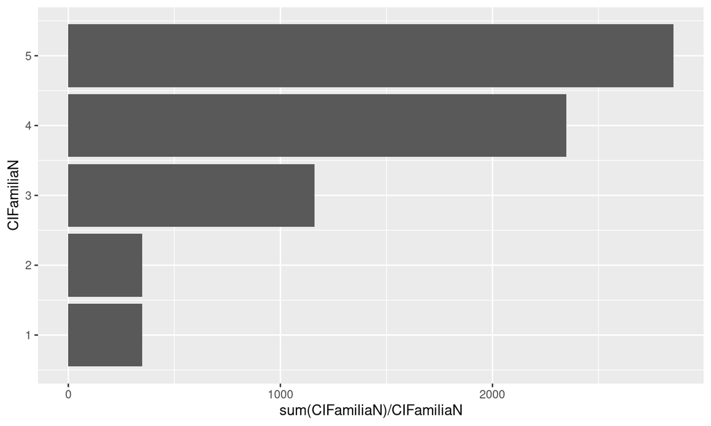

## Análisis

### Calidad de interacción con Familia General

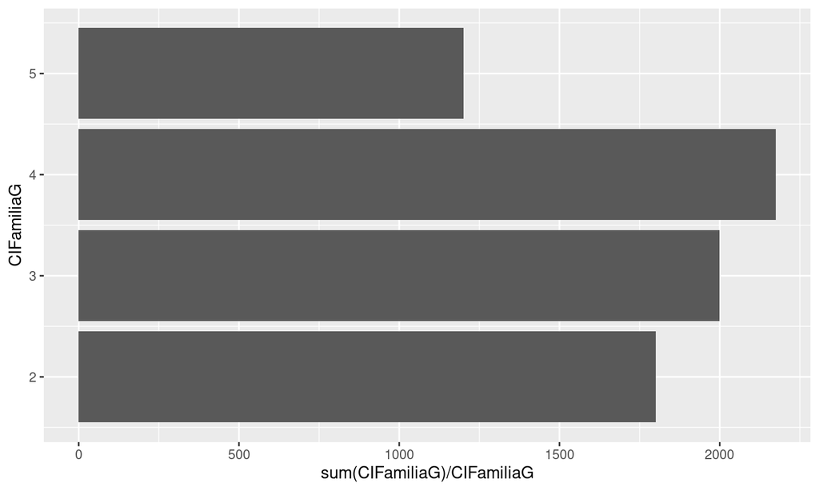

## Análisis

### Calidad de interacción con Amigos

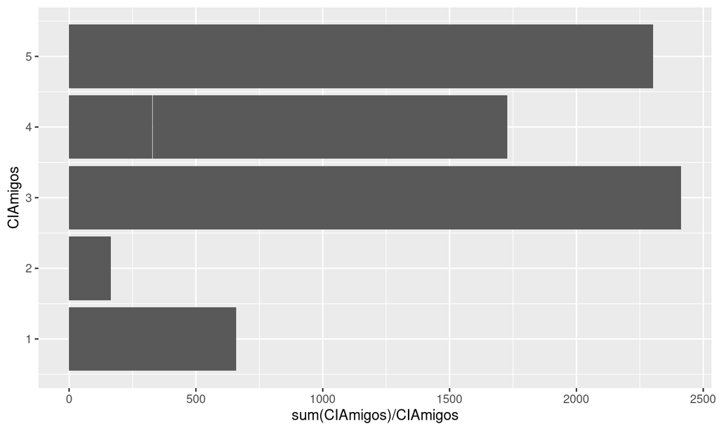